# APS1070

#### Project 1 --- Basic Principles and Models

**Deadline: Oct 6th, 9PM - 10 percent**

**Academic Integrity**

This project is individual - it is to be completed on your own. If you have questions, please post your query in the APS1070 Piazza Q&A forums (the answer might be useful to others!).

Do not share your code with others, or post your work online. Do not submit code that you have not written yourself. Students suspected of plagiarism on a project, midterm or exam will be referred to the department for formal discipline for breaches of the Student Code of Conduct.

Name: Ziruo Song

Student ID: 1005637198

## **Marking Scheme:**

This project is worth **10 percent** of your final grade.

Draw a plot or table where necessary to summarize your findings.

**Practice Vectorized coding**: If you need to write a loop in your solution, think about how you can implement the same functionality with vectorized operations. Try to avoid loops as much as possible (in some cases, loops are inevitable).

### How to submit **(HTML + IPYNB)**

1. Download your notebook: `File -> Download .ipynb`
2. Click on the Files icon on the far left menu of Colab
3. Select & upload your `.ipynb` file you just downloaded, and then obtain its path (right click) (you might need to hit the Refresh button before your file shows up)
1. execute the following in a Colab cell:

   ```
   %%shell
   jupyter nbconvert --to html /PATH/TO/YOUR/NOTEBOOKFILE.ipynb
   ```

2. An HTML version of your notebook will appear in the files, so you can download it.
3. Submit **both** `HTML` and `IPYNB` files on Quercus for grading.

Ref: https://stackoverflow.com/a/64487858

# Project 1 [10 Marks]

Let's apply the tools we have learned in the tutorial to a new dataset.

We're going to work with a breast cancer dataset. Download it using the cell below:

```python
from sklearn.datasets import load_breast_cancer
dataset = load_breast_cancer()
```

## Part 1: Getting started [2 Marks]

First off, take a look at the `data`, `target` and `feature_names` entries in the `dataset` dictionary. They contain the information we'll be working with here. Then, create a Pandas DataFrame called `df` containing the data and the targets, with the feature names as column headings. If you need help, see [here](https://pandas.pydata.org/pandas-docs/stable/reference/api/pandas.DataFrame.html) for more details on how to achieve this. **[0.4]**

- How many features do we have in this dataset? 30
- How many observations have a 'mean area' of greater than 700? 171
- How many participants tested `Malignant`? 212
- How many participants tested `Benign`? 357

```python
dataset
```

[output not shown]

```python
import pandas as pd
df = pd.DataFrame(dataset.data, columns=dataset.feature_names)
df['target']=dataset.target
df
```

|  | mean radius | mean texture | mean perimeter | mean area | mean smoothness | mean compactness | mean concavity | mean concave points | mean symmetry | mean fractal dimension | ... | worst texture | worst perimeter | worst area | worst smoothness | worst compactness | worst concavity | worst concave points | worst symmetry | worst fractal dimension | target |
| --- | --- | --- | --- | --- | --- | --- | --- | --- | --- | --- | --- | --- | --- | --- | --- | --- | --- | --- | --- | --- | --- |
| 0 | 17.99 | 10.38 | 122.80 | 1001.0 | 0.11840 | 0.27760 | 0.30010 | 0.14710 | 0.2419 | 0.07871 | ... | 17.33 | 184.60 | 2019.0 | 0.16220 | 0.66560 | 0.7119 | 0.2654 | 0.4601 | 0.11890 | 0 |
| 1 | 20.57 | 17.77 | 132.90 | 1326.0 | 0.08474 | 0.07864 | 0.08690 | 0.07017 | 0.1812 | 0.05667 | ... | 23.41 | 158.80 | 1956.0 | 0.12380 | 0.18660 | 0.2416 | 0.1860 | 0.2750 | 0.08902 | 0 |
| 2 | 19.69 | 21.25 | 130.00 | 1203.0 | 0.10960 | 0.15990 | 0.19740 | 0.12790 | 0.2069 | 0.05999 | ... | 25.53 | 152.50 | 1709.0 | 0.14440 | 0.42450 | 0.4504 | 0.2430 | 0.3613 | 0.08758 | 0 |
| 3 | 11.42 | 20.38 | 77.58 | 386.1 | 0.14250 | 0.28390 | 0.24140 | 0.10520 | 0.2597 | 0.09744 | ... | 26.50 | 98.87 | 567.7 | 0.20980 | 0.86630 | 0.6869 | 0.2575 | 0.6638 | 0.17300 | 0 |
| 4 | 20.29 | 14.34 | 135.10 | 1297.0 | 0.10030 | 0.13280 | 0.19800 | 0.10430 | 0.1809 | 0.05883 | ... | 16.67 | 152.20 | 1575.0 | 0.13740 | 0.20500 | 0.4000 | 0.1625 | 0.2364 | 0.07678 | 0 |
| ... | ... | ... | ... | ... | ... | ... | ... | ... | ... | ... | ... | ... | ... | ... | ... | ... | ... | ... | ... | ... | ... |
| 564 | 21.56 | 22.39 | 142.00 | 1479.0 | 0.11100 | 0.11590 | 0.24390 | 0.13890 | 0.1726 | 0.05623 | ... | 26.40 | 166.10 | 2027.0 | 0.14100 | 0.21130 | 0.4107 | 0.2216 | 0.2060 | 0.07115 | 0 |
| 565 | 20.13 | 28.25 | 131.20 | 1261.0 | 0.09780 | 0.10340 | 0.14400 | 0.09791 | 0.1752 | 0.05533 | ... | 38.25 | 155.00 | 1731.0 | 0.11660 | 0.19220 | 0.3215 | 0.1628 | 0.2572 | 0.06637 | 0 |
| 566 | 16.60 | 28.08 | 108.30 | 858.1 | 0.08455 | 0.10230 | 0.09251 | 0.05302 | 0.1590 | 0.05648 | ... | 34.12 | 126.70 | 1124.0 | 0.11390 | 0.30940 | 0.3403 | 0.1418 | 0.2218 | 0.07820 | 0 |
| 567 | 20.60 | 29.33 | 140.10 | 1265.0 | 0.11780 | 0.27700 | 0.35140 | 0.15200 | 0.2397 | 0.07016 | ... | 39.42 | 184.60 | 1821.0 | 0.16500 | 0.86810 | 0.9387 | 0.2650 | 0.4087 | 0.12400 | 0 |
| 568 | 7.76 | 24.54 | 47.92 | 181.0 | 0.05263 | 0.04362 | 0.00000 | 0.00000 | 0.1587 | 0.05884 | ... | 30.37 | 59.16 | 268.6 | 0.08996 | 0.06444 | 0.0000 | 0.0000 | 0.2871 | 0.07039 | 1 |

569 rows × 31 columns

```python
print("Number of features: ", len(dataset.feature_names))
print("Number of observations whose 'mean area' is greater than 700: ", sum(df['mean area']>700) )
print("Number of participants tested `Malignant`:", sum(df.target== 0))
print("Number of participants tested `Benign`:", sum(df.target== 1))
```

```
Number of features:  30
Number of observations whose 'mean area' is greater than 700:  171
Number of participants tested `Malignant`: 212
Number of participants tested `Benign`: 357
```

### Splitting the data

It is best practice to have a training set (from which there is a rotating validation subset) and a test set. Our aim here is to (eventually) obtain the best accuracy we can on the test set (we'll do all our tuning on the training/validation sets, however.)

**Split the dataset** into a train and a test set **"70:30"**, use **`random_state=0`**. The test set is set aside (untouched) for final evaluation, once hyperparameter optimization is complete. **[0.5]**

**Only Split the dataset once within you notebook.** You should not use the `train_test_split` function more than once, regardless of the random state. Keep this in mind for your future projects as well.

```python
from sklearn.model_selection import train_test_split
X=dataset.data
y=dataset.target
X_train, X_test, y_train, y_test = train_test_split(X, y, test_size=0.3, random_state=0)
```

### Effect of Standardization (Visual)

Use `seaborn.lmplot` ([help here](https://seaborn.pydata.org/generated/seaborn.lmplot.html)) to visualize a few features of the training set. Draw a plot where the x-axis is `worst smoothness`, the y-axis is `worst fractal dimension,` and the color of each datapoint indicates its class. **[0.5]**

Standardizing the data is often critical in machine learning. Show a plot as above, but with two features with very different scales. Standardize the data and plot those features again. What's different? **why do they look similar?** Based on your observation, what is the advantage of standardization? **[0.6]**

```python
# show the train data indcluding the target value
my_train = pd.DataFrame(X_train, columns=dataset.feature_names)
my_train['target']=y_train
my_train
```

|  | mean radius | mean texture | mean perimeter | mean area | mean smoothness | mean compactness | mean concavity | mean concave points | mean symmetry | mean fractal dimension | ... | worst texture | worst perimeter | worst area | worst smoothness | worst compactness | worst concavity | worst concave points | worst symmetry | worst fractal dimension | target |
| --- | --- | --- | --- | --- | --- | --- | --- | --- | --- | --- | --- | --- | --- | --- | --- | --- | --- | --- | --- | --- | --- |
| 0 | 11.490 | 14.59 | 73.99 | 404.9 | 0.10460 | 0.08228 | 0.05308 | 0.01969 | 0.1779 | 0.06574 | ... | 21.90 | 82.04 | 467.6 | 0.13520 | 0.20100 | 0.25960 | 0.07431 | 0.2941 | 0.09180 | 1 |
| 1 | 10.490 | 18.61 | 66.86 | 334.3 | 0.10680 | 0.06678 | 0.02297 | 0.01780 | 0.1482 | 0.06600 | ... | 24.54 | 70.76 | 375.4 | 0.14130 | 0.10440 | 0.08423 | 0.06528 | 0.2213 | 0.07842 | 1 |
| 2 | 12.250 | 17.94 | 78.27 | 460.3 | 0.08654 | 0.06679 | 0.03885 | 0.02331 | 0.1970 | 0.06228 | ... | 25.22 | 86.60 | 564.2 | 0.12170 | 0.17880 | 0.19430 | 0.08211 | 0.3113 | 0.08132 | 1 |
| 3 | 18.310 | 18.58 | 118.60 | 1041.0 | 0.08588 | 0.08468 | 0.08169 | 0.05814 | 0.1621 | 0.05425 | ... | 26.36 | 139.20 | 1410.0 | 0.12340 | 0.24450 | 0.35380 | 0.15710 | 0.3206 | 0.06938 | 0 |
| 4 | 6.981 | 13.43 | 43.79 | 143.5 | 0.11700 | 0.07568 | 0.00000 | 0.00000 | 0.1930 | 0.07818 | ... | 19.54 | 50.41 | 185.2 | 0.15840 | 0.12020 | 0.00000 | 0.00000 | 0.2932 | 0.09382 | 1 |
| ... | ... | ... | ... | ... | ... | ... | ... | ... | ... | ... | ... | ... | ... | ... | ... | ... | ... | ... | ... | ... | ... |
| 393 | 18.810 | 19.98 | 120.90 | 1102.0 | 0.08923 | 0.05884 | 0.08020 | 0.05843 | 0.1550 | 0.04996 | ... | 24.30 | 129.00 | 1236.0 | 0.12430 | 0.11600 | 0.22100 | 0.12940 | 0.2567 | 0.05737 | 0 |
| 394 | 12.460 | 24.04 | 83.97 | 475.9 | 0.11860 | 0.23960 | 0.22730 | 0.08543 | 0.2030 | 0.08243 | ... | 40.68 | 97.65 | 711.4 | 0.18530 | 1.05800 | 1.10500 | 0.22100 | 0.4366 | 0.20750 | 0 |
| 395 | 9.436 | 18.32 | 59.82 | 278.6 | 0.10090 | 0.05956 | 0.02710 | 0.01406 | 0.1506 | 0.06959 | ... | 25.02 | 75.79 | 439.6 | 0.13330 | 0.10490 | 0.11440 | 0.05052 | 0.2454 | 0.08136 | 1 |
| 396 | 9.720 | 18.22 | 60.73 | 288.1 | 0.06950 | 0.02344 | 0.00000 | 0.00000 | 0.1653 | 0.06447 | ... | 20.83 | 62.25 | 303.8 | 0.07117 | 0.02729 | 0.00000 | 0.00000 | 0.1909 | 0.06559 | 1 |
| 397 | 11.510 | 23.93 | 74.52 | 403.5 | 0.09261 | 0.10210 | 0.11120 | 0.04105 | 0.1388 | 0.06570 | ... | 37.16 | 82.28 | 474.2 | 0.12980 | 0.25170 | 0.36300 | 0.09653 | 0.2112 | 0.08732 | 1 |

398 rows × 31 columns

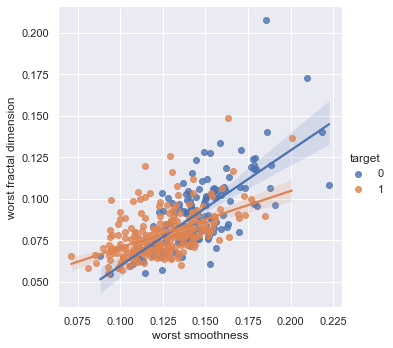

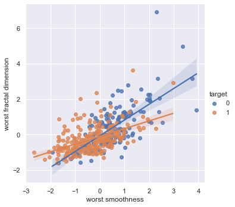

```python
# Before standardizing the data
import seaborn as sns; sns.set_theme(color_codes=True)
g1 = sns.lmplot(data = my_train, x="worst smoothness", y="worst fractal dimension",hue="target")

# After standardizing
from sklearn import preprocessing

scaler = preprocessing.StandardScaler().fit(X_train)
X_scaled = scaler.transform(X_train)
train_scaled = pd.DataFrame(X_scaled, columns=dataset.feature_names)
train_scaled['target']=y_train
g2 = sns.lmplot(data = train_scaled, x="worst smoothness", y="worst fractal dimension",hue="target")

#Conclusion: The main difference are the scales of x-axis and y-axis, but the points scattered and distributions
# are similar. Since the values were changed to the difference with the mean value of relative feature,
# the distribution would remain the same, as only the units are changed.
# With standardization, the comparison of the data could be easier regardless of the units, like we got some
# small integers around 0 for both axises, instead of floats with 3 decimals in the example. Besides, the
# relationships between each value and the mean value can be shown more clear with the sign of the scaled values.
```

## Part 2: KNN Classifier without Standardization [2 Marks]

Normally, standardizing data is a key step in preparing data for a KNN classifier. However, for educational purposes, let's first try to build a model without standardization. Let's create a KNN classifier to predict whether a patient has a malignant or benign tumor.

Follow these steps:

1. Train a KNN Classifier using cross-validation on the dataset. Sweep `k` (number of neighbours) from 1 to 100, and show a plot of the mean cross-validation accuracy vs `k`. **[1]**
2. What is the best `k`? What is the highest cross-validation accuracy? **[0.5]**
3. Comment on which ranges of `k` lead to underfitted or overfitted models (hint: compare training and validation curves!). **[0.5]**

```python
# get the mean cross-validation accuracy for each k value, in a list named 'accuracy'
from sklearn.model_selection import cross_validate
from sklearn import neighbors
accuracy =[]
for i in list(range(1,101)):
    knn_i= neighbors.KNeighborsClassifier(n_neighbors=i)
    targets = cross_validate(knn_i, X_train, y_train, cv=5, return_train_score=True)
    ave=targets['test_score'].mean()
    accuracy.append(ave)
```

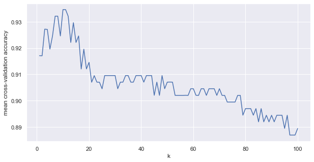

```python
# polt the mean cross-validation accuracy v.s. k value
import matplotlib.pyplot as plt
import numpy as np
plt.figure(figsize=(10,5))
plt.plot(np.arange(1, 101, 1, dtype=int), np.array(accuracy))
plt.xlabel('k')
plt.ylabel('mean cross-validation accuracy')
plt.grid(True)
```

```python
# get the best k with highest accuracy value
print("the best k = ",accuracy.index(max(accuracy))+1, "with the highest cross-validation accuracy of",
      max(accuracy)*100,"%")
```

```
the best k =  10 with the highest cross-validation accuracy of 93.46518987341771 %
```

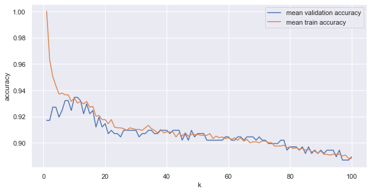

```python
# ranges of k lead to underfitted or overfitted models
# draw mean accuracy of test data
accuracy_2 =[]
for i in list(range(1,101)):
    knn_i= neighbors.KNeighborsClassifier(n_neighbors=i)
    targets = cross_validate(knn_i, X_train, y_train, cv=5, return_train_score=True)
    ave2=targets['train_score'].mean()
    accuracy_2.append(ave2)

plt.figure(figsize=(10,5))
plt.plot(np.arange(1, 101, 1, dtype=int), np.array(accuracy),label="mean validation accuracy")
plt.plot(np.arange(1, 101, 1, dtype=int), np.array(accuracy_2),label="mean train accuracy")
plt.xlabel('k')
plt.ylabel('accuracy')
plt.legend()
plt.grid(True)
```

comment:

From k=1 to k=10,the mean train accuracy exceeded mean validation accuracy quite obviously, indicating thay lead to overfitted models with good performances on the training data, but poorer accuracy for validation data. As the amount of neighbours increased above k=10, there was no obvious trend between the differences of the two lines. So we say k<10 leads to overfitted models.

## Part 3: Feature Selection [3 Marks]

In this part, we aim to investigate the importance of each feature on the final classification accuracy. If we want to try every possible combination of features, we would have to test $2^F$ different cases, where F is the number of features, and in each case, we have to do a hyperparameter search (finding K, in KNN using cross-validation). That will take days!.

To find more important features we will use a decision tree. based on a decision tree we can compute feature importance that is a metric for our feature selection (code is provided below).

You can use [this link](https://machinelearningmastery.com/calculate-feature-importance-with-python/) to get familiar with extracting the feature impotance order of machine learning algorithms in Python.

After we identified and removed the least important feature and evaluated a new KNN model on the new set of features, if the stop conditions (see step 7 below) are not met, we need to repeat the process and remove another feature.

Design a function ( `Feature_selector`) that accepts your dataset (X_train , y_train) and a threshold as inputs and: **[1]**

1. Fits a decision tree classifier on the training set.
2. Extracts the feature importance order of the decision tree model.
3. Removes the least important feature based on step 2.
4. Then, a KNN model is trained on the remaining features. The number of neighbors (`k`) for each KNN model should be tuned using a 5-fold cross-validation.
5. Store the best `mean cross-validation` score and the corresponding `k` (number of neighbours) value in two lists.
6. Go back to step 3 and follow all the steps until you meet the stop condition (step 7).
7. We will stop this process when (1) there is only one feature left, or (2) our cross-validation accuracy is dropped significantly compared to a model that uses all the features. In this function, we accept a threshold as an input argument. For example, if threshold=0.95 we do not continue removing features if our mean cross-validation accuracy after tuning `k` is bellow **0.95 $\times$ Full Feature cross-validation accuracy**.
8. Your function returns the list of removed features, and the corresponding mean cross-validation accuracy and `k` value when a feature was removed.
- Visualize your results by plotting the mean cross-validation accuracy (with a tuned `k` on y axis) vs. the on the number of features (x axis). This plot describes: what is the best cv score with 1 feature, 2 features, 3 features ... and all the features. **[0.5]**
- Plot the best value of `k` (y-axis) vs. the number of features. This plot explains the trend of number of neighbours with respect to the number of features. **[0.5]**
- State what is the number of essential features for classification and justify your answer. **[1]**

```python
def Feature_selector (X_train , y_train , tr=0.95):
# step1: use given code to train a decision tree classifier and obtain its feature importance
    from sklearn import tree
    dt = tree.DecisionTreeClassifier()
    dt.fit(X_train,y_train)
    importance = dt.feature_importances_

# step2: sort the feature importance order in decreasing order(1st:most important)
    import_df=pd.DataFrame({'feature':dataset.feature_names,'importance':importance})
    import_sort = import_df.sort_values('importance',ascending=False)         #sort importance df

# step3: remove the feature(s) with the least value of importance
    removed_feature = []
    best_accuracy = [1]
    relative_k=[]
    removed_id = []

###step 6: loop for reducing a feature once a time ###
    while best_accuracy[-1]>= tr * max(accuracy) and len(removed_feature)<29:
        min_imp_id= import_sort.index[-1] #get index of min importance value
        removed_id.append(min_imp_id)
        removed_feature.append(import_sort.feature[min_imp_id])#add reduced feature(s) to the list

#step4: train KNN model on the remaining features
        acrc=[]
        for i in list(range(1,101)):
            new_X_train =np.delete(X_train, removed_id, axis = 1) #del feature from x train
            knn= neighbors.KNeighborsClassifier(n_neighbors=i)
            targets = cross_validate(knn, new_X_train , y_train, cv=5, return_train_score=True)
            ave=targets['test_score'].mean()
            acrc.append(ave)
# Store the best mean cross-validation score and the corresponding k value in two lists
        best_accuracy.append(max(acrc))
        relative_k.append(acrc.index(max(acrc))+1)
        import_sort=import_sort[0:-1]                      #update importance df containing remaining feature

    return [removed_feature,best_accuracy[1:],relative_k]


fs=Feature_selector (X_train , y_train , tr=0.95)
fs
```

```
[['worst fractal dimension',
  'mean perimeter',
  'mean area',
  'mean smoothness',
  'mean compactness',
  'mean concave points',
  'mean fractal dimension',
  'radius error',
  'texture error',
  'perimeter error',
  'symmetry error',
  'mean radius',
  'worst area',
  'worst compactness',
  'worst smoothness',
  'fractal dimension error',
  'worst perimeter',
  'smoothness error',
  'mean concavity',
  'compactness error',
  'concave points error',
  'worst symmetry',
  'concavity error',
  'mean texture',
  'mean symmetry',
  'worst texture',
  'worst concavity',
  'area error',
  'worst radius'],
 [0.9346518987341772,
  0.9346518987341772,
  0.9145886075949367,
  0.9145886075949367,
  0.9145886075949367,
  0.9145886075949367,
  0.9145886075949367,
  0.9145886075949367,
  0.9145886075949367,
  0.9145886075949367,
  0.9145886075949367,
```

[output cut: 32 more lines]

```
  20,
  20,
  12,
  12,
  12,
  12,
  12,
  12,
  12,
  5,
  5,
  3,
  3,
  38,
  34]]
```

# Visualize results by plotting the mean cross-validation accuracy (with a tuned k on y axis) vs. the on the number of features (x axis).

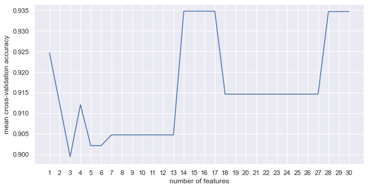

```python
plt.figure(figsize=(10,5))
x=list(range(1,31))
y=list(reversed(fs[1]))
y.append(max(accuracy))
plt.plot(x,y)
plt.xlabel('number of features')
plt.ylabel('mean cross-validation accuracy')
plt.xticks(range(1, 31))
plt.grid(True)
```

# Plot the best value of k (y-axis) vs. the number of features.

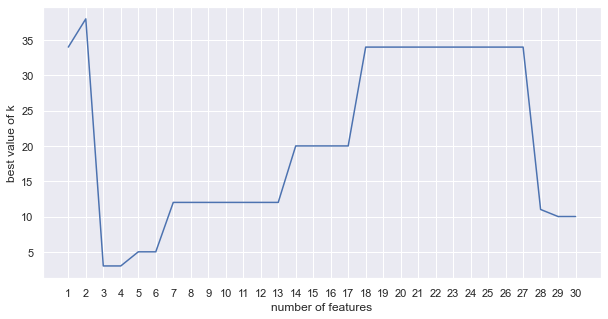

```python
plt.figure(figsize=(10,5))
x_value = list(range(1,31))
y_value=list(reversed(fs[2]))
y_value.append(accuracy.index(max(accuracy))+1)
plt.plot(x_value,y_value)
plt.xlabel('number of features')
plt.ylabel('best value of k')
plt.xticks(range(1, 31))
plt.grid(True)
```